# Step-selection function: Exericise 1

For this exercise, you will work with Scott Lapoint’s fisher data:

LaPoint, S, Gallery P, Wikelski M, Kays R (2013) Animal behavior, cost-based corridor models, and real corridors. Landscape Ecology, v 28 i 8, p 1615–1630. doi:10.1007/s10980-013-9910-0

LaPoint S, Gallery P, Wikelski M, Kays R (2013) Data from: Animal behavior, cost-based corridor models, and real corridors. Movebank Data Repository. doi:10.5441/001/1.2tp2j43g

Or, alternatively, feel free to work with your own data!

Let’s load packages we will need.

```r
library(amt)
library(terra)
library(tidyverse)
library(here)
```

It will help to have the `amt_demo_iSSF.html` file open as you work through the exercise.

First, we will read in the data and environmental layers capturing elevation, population density, and landuse categories. We will center and scale the covariate data and also create an indicator variable that is 1 if the observation is in forest and 0 otherwise.

```r
# Location data
dat <- read_csv(here("Resource-and-Step-Selection-Analyses/Data", "fisher_data.csv"))
```

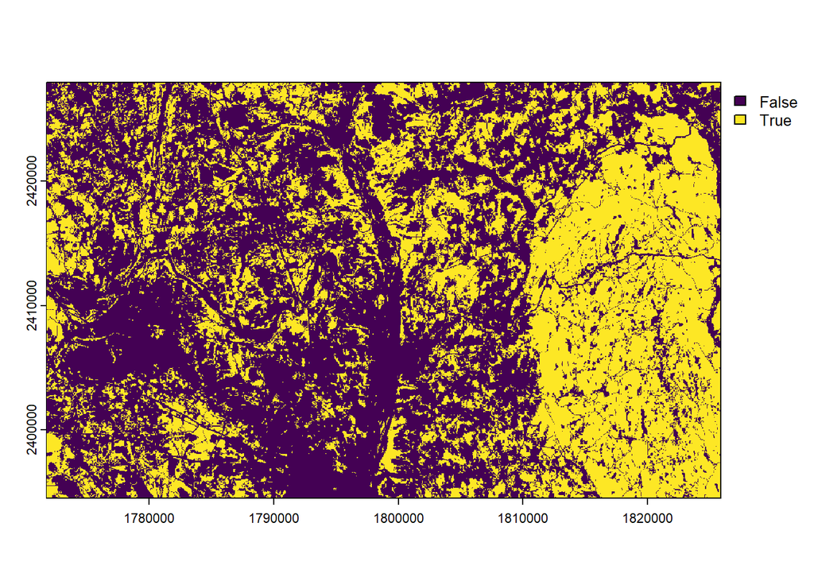

```r
# Environmental layers
elevation <- rast(here("Resource-and-Step-Selection-Analyses/Data/elevation/", "ASTER ASTGTM2 Elevation-20100101120000000-0-0.tif"))
landuse <- rast(here("Resource-and-Step-Selection-Analyses/Data/landuse", "landuse_study_area.tif"))
popden <- rast(here("Resource-and-Step-Selection-Analyses/Data/pop_den", "pop_den.tif"))

# Center and scale elevation and popden
elevation[] <- (elevation[] - mean(elevation[], na.rm = TRUE))/sd(elevation[], na.rm = TRUE)
popden[] <- (popden[] - mean(popden[], na.rm = TRUE))/sd(popden[], na.rm = TRUE)

# Reproject rasters to EPSG:5070
landuse <- project(landuse, "EPSG:5070")
elevation <- project(elevation, "EPSG:5070")
popden <- project(popden, "EPSG:5070")

# Create a binary layer where landuse classes 41 to 43 represent forest
forest <- landuse %in% 41:43

# Plot forest
plot(forest)
```

```r
# Rename the layers
names(elevation)<-"elevation"
names(forest)<-"forest"
names(popden)<-"popden"
```

1. Filter the data to include observations from one of the individuals (feel free to choose a different individual).

```r
dat <- dat %>%
  filter(id == 1072)
dat
```

```
## # A tibble: 1,349 × 4
##        x     y t                      id
##    <dbl> <dbl> <dttm>              <dbl>
##  1 -73.9  42.8 2011-02-11 18:06:14  1072
##  2 -73.9  42.8 2011-02-11 18:10:09  1072
##  3 -73.9  42.8 2011-02-11 18:20:59  1072
##  4 -73.9  42.8 2011-02-11 18:41:31  1072
##  5 -73.9  42.8 2011-02-11 19:41:11  1072
##  6 -73.9  42.8 2011-02-11 19:50:58  1072
##  7 -73.9  42.8 2011-02-11 20:01:13  1072
##  8 -73.9  42.8 2011-02-12 23:31:32  1072
##  9 -73.9  42.8 2011-02-12 23:50:57  1072
## 10 -73.9  42.8 2011-02-13 00:00:13  1072
## # ℹ 1,339 more rows
```

2. Create a track using the `make_track` function. Use the arguement crs = 4326. Then, use transform_coords to transform the track to crs 5070.

```r
trk <- make_track(dat, .x = x, .y = y, .t = t, crs = 4326)
trk <- trk %>% transform_coords(crs_to = 5070)
```

3. Check the sampling rate of the observations using the `summarize_sampling_rate`.

```r
summarize_sampling_rate(trk)
```

```
## # A tibble: 1 × 9
##     min    q1 median  mean    q3   max    sd     n unit
##   <dbl> <dbl>  <dbl> <dbl> <dbl> <dbl> <dbl> <int> <chr>
## 1  3.92   9.8   10.0  20.7  10.3 1650.  95.2  1348 min
```

4. Use `track_resample` to choose an appropriate sampling frequency to model movements. Note: there are many options here, but the median time interval is 10 minutes (so, that is the shortest sampling frequency we should choose).

```r
trk2 <-track_resample(trk, rate = minutes(10), tolerance = minutes(1))
```

5. Create a *steps* version fo the data using the `steps_by_burst` function.

```r
fishersteps <- steps_by_burst(trk2)
```

5. Plot the empirical distribution of step lengths and turn angles.

The distribution of step lengths is highly right skewed. There are some really large step lengths that should probably be looked at to make sure they are reasonable (these may be due to large measurement errors).

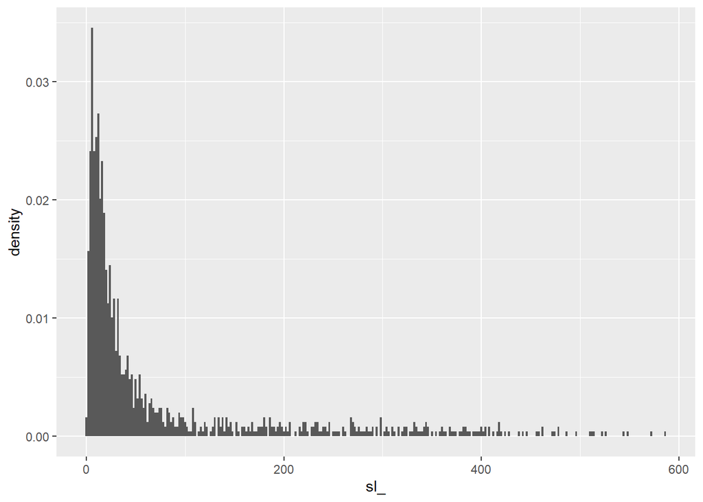

```r
ggplot(fishersteps, aes(x = sl_)) +
  geom_histogram(aes(y = ..density..), binwidth = 2)
```

The distribution of turn angles is multi-modal with modes at 0 and +/- $\pi$ (as if often the case).

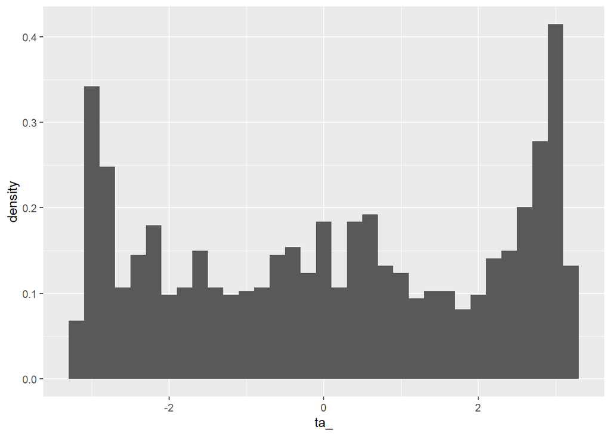

```r
ggplot(fishersteps, aes(x = ta_)) +
  geom_histogram(aes(y = ..density..), binwidth = 0.2)
```

6. Use the `random_steps` function to: a) fit a gamma distribution to the step lenghts and a von-Mises distribution to the turn angles, and b) generate 20 random steps for each observed step.

```r
obsavail <- random_steps(fishersteps, n_control = 20)
```

7. Extract covariates for population, elevation, and forest. You can choose whether to extract these covariate values at the start of the step, end of the step, or both.

```r
ssfdat <- obsavail %>%
  extract_covariates(elevation, where = "both") %>%
  extract_covariates(forest, where = "end") %>%
  extract_covariates(popden, where = "end") %>%
  mutate(log_sl_ = log(sl_))
```

8. Fit a step-selection model to the data form step 7.

```r
m1 <- fit_issf(ssfdat,
               case_ ~ elevation_end + forest + popden +
                 sl_ + log_sl_ + cos(ta_) + (sl_+log_sl_):elevation_start +
               strata(step_id_),
               model=TRUE)
summary(m1)
```

```
## Call:
## coxph(formula = Surv(rep(1, 24339L), case_) ~ elevation_end +
##     forest + popden + sl_ + log_sl_ + cos(ta_) + (sl_ + log_sl_):elevation_start +
##     strata(step_id_), data = data, model = TRUE, method = "exact")
##
##   n= 24339, number of events= 1159
##
##                              coef exp(coef)  se(coef)       z Pr(>|z|)
## elevation_end            2.467732 11.795666  1.223869   2.016   0.0438 *
## forestTRUE               0.863481  2.371400  0.106531   8.105 5.26e-16 ***
## popden                  -0.525113  0.591488  0.296583  -1.771   0.0766 .
## sl_                      0.015357  1.015476  0.007417   2.070   0.0384 *
## log_sl_                  0.468212  1.597137  0.371618   1.260   0.2077
## cos(ta_)                -0.689949  0.501602  0.043732 -15.777  < 2e-16 ***
## sl_:elevation_start      0.016313  1.016447  0.008272   1.972   0.0486 *
## log_sl_:elevation_start  0.518247  1.679082  0.407979   1.270   0.2040
## ---
## Signif. codes:  0 '***' 0.001 '**' 0.01 '*' 0.05 '.' 0.1 ' ' 1
##
##                         exp(coef) exp(-coef) lower .95 upper .95
## elevation_end             11.7957    0.08478    1.0714  129.8619
## forestTRUE                 2.3714    0.42169    1.9245    2.9220
## popden                     0.5915    1.69065    0.3307    1.0578
## sl_                        1.0155    0.98476    1.0008    1.0303
## log_sl_                    1.5971    0.62612    0.7709    3.3088
## cos(ta_)                   0.5016    1.99361    0.4604    0.5465
## sl_:elevation_start        1.0164    0.98382    1.0001    1.0331
## log_sl_:elevation_start    1.6791    0.59556    0.7547    3.7355
##
## Concordance= 0.662  (se = 0.009 )
## Likelihood ratio test= 373.9  on 8 df,   p=<2e-16
## Wald test            = 346.6  on 8 df,   p=<2e-16
## Score (logrank) test = 369.1  on 8 df,   p=<2e-16
```

9. Interpret the parameters in terms of relative probability of use.

10. Plot updated step length and turn angle distributions.

Tentative distribution

```r
tent_sl <- sl_distr(m1)
```

Because we have an interaction between the step length variables and a continuous variable, we have to use the `update_gamma` function as outlined in [Appendix B of Fieberg et al. 2021](https://conservancy.umn.edu/server/api/core/bitstreams/63727072-87b1-4b35-b81c-8fd31b8f1e57/content).

```r
elevs.025 <- quantile(ssfdat$elevation_start, prob = 0.025)
upd_sl_low <- update_gamma(dist = m1$sl_,
                           beta_sl = m1$model$coefficients["sl_"] +
                               elevs.025*m1$model$coefficients["sl_:elevation_start"],
                           beta_log_sl = m1$model$coefficients["log_sl_"] +
                               elevs.025*m1$model$coefficients["log_sl_:elevation_start"])
```

```r
elevs.975 <- quantile(ssfdat$elevation_start, prob = 0.975)
upd_sl_high <- update_gamma(dist = m1$sl_,
                           beta_sl = m1$model$coefficients["sl_"] +
                              elevs.975*m1$model$coefficients["sl_:elevation_start"],
                           beta_log_sl = m1$model$coefficients["log_sl_"] +
                             elevs.975*m1$model$coefficients["log_sl_:elevation_start"])
```

Put these all together and plot the distributions.

```r
tent_df <- data.frame(dist = "tent",
                      shp = tent_sl$params$shape,
                      scl = tent_sl$params$scale)
upd_high <- data.frame(dist = "upd High",
                     shp = upd_sl_high$params$shape,
                     scl = upd_sl_high$params$scale)
upd_low <- data.frame(dist = "upd Low",
                     shp = upd_sl_low$params$shape,
                     scl = upd_sl_low$params$scale)
(sl_df <- rbind(tent_df, upd_high, upd_low))
```

```
##       dist       shp      scl
## 1     tent 0.6484162 115.3721
## 2 upd High 0.6966000 153.0890
## 3  upd Low 0.5941138 102.4778
```

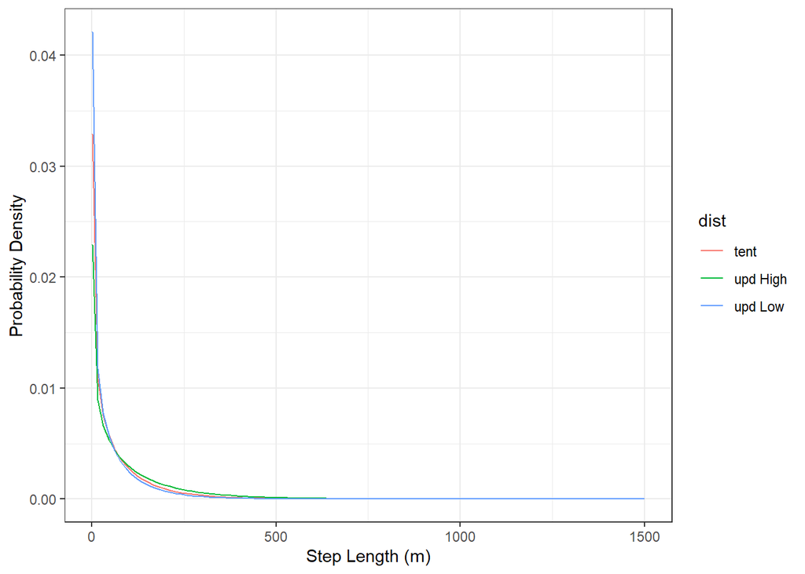

```r
expand.grid(sl = seq(1, 1500, length.out = 100),
            dist = c("tent", "upd High", "upd Low")) %>%
  left_join(sl_df) %>%
  mutate(y = dgamma(sl, shape = shp, scale = scl)) %>%
  ggplot(aes(x = sl, y = y, color = dist)) +
  geom_line() +
  xlab("Step Length (m)") +
  ylab("Probability Density") +
  theme_bw()
```

Mean step length for the gamma = shape * scale parameter

```r
sl_df$mean = sl_df$shp*sl_df$scl
sl_df
```

```
##       dist       shp      scl      mean
## 1     tent 0.6484162 115.3721  74.80913
## 2 upd High 0.6966000 153.0890 106.64177
## 3  upd Low 0.5941138 102.4778  60.88348
```

Now, let’s look at the turn angle distribution. First, we update the parameters.

```r
tent_ta <- ta_distr(m1)
upd_ta <- update_ta_distr(m1, beta_cos_ta = "cos(ta_)")
tent_df_ta <- data.frame(dist = "tent",
                         mu = tent_ta$params$mu,
                         k = tent_ta$params$kappa)
(upd_df_ta <- data.frame(dist = "upd",
                        mu = upd_ta$params$mu,
                        k = upd_ta$params$kappa))
```

```
##   dist mu          k
## 1  upd  0 -0.3449597
```

The von Mises is not defined for negative kappa. Negative kappa indicates that the turns are not actually concentrated around 0 (as we typically assume), but rather are concentrated around +/- pi. If this happens, we can simply multiply the estimated kappa by -1 and change mu to pi.

```r
upd_df_ta <- data.frame(dist = "upd",
                        mu = pi,
                        k = -1 * upd_ta$params$kappa)
(ta_df <- rbind(tent_df_ta, upd_df_ta))
```

```
##   dist       mu         k
## 1 tent 0.000000 0.3449890
## 2  upd 3.141593 0.3449597
```

Plot the distribution.

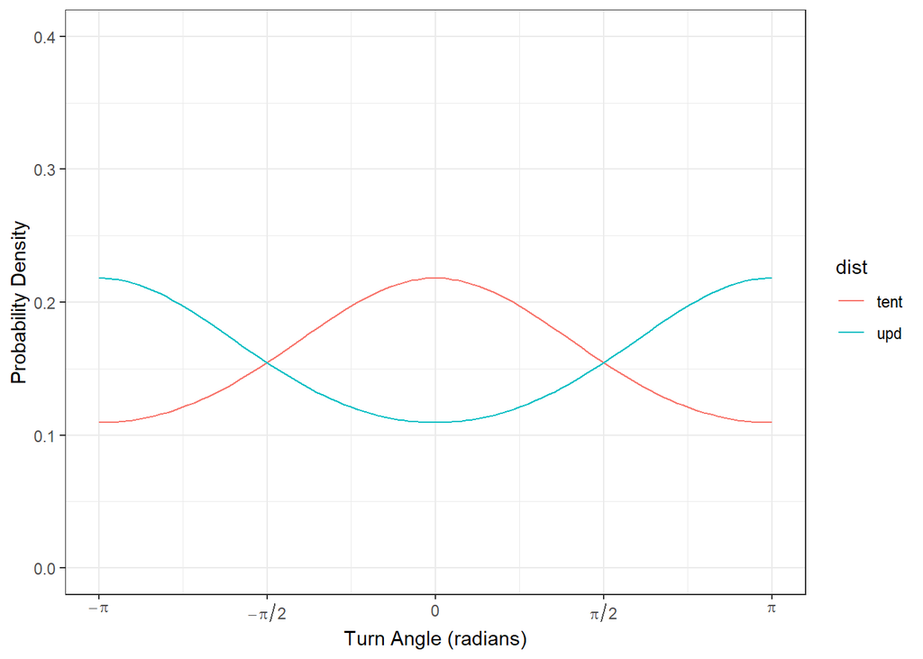

```r
expand.grid(ta = seq(-pi, pi, length.out = 100),
            dist = c("tent", "upd")) %>%
  left_join(ta_df) %>%
  # circular::dvonmises is not vectorized
  rowwise() %>%
  mutate(y = circular::dvonmises(ta, mu = mu, kappa = k)) %>%
  ggplot(aes(x = ta, y = y, color = dist)) +
  geom_line() +
  xlab("Turn Angle (radians)") +
  ylab("Probability Density") +
  scale_x_continuous(breaks = c(-pi, -pi/2, 0, pi/2, pi),
                     labels = expression(-pi, -pi/2, 0, pi/2, pi)) +
  coord_cartesian(ylim = c(0, 0.4)) +
  theme_bw()
```